# War Versus Peace

### Background

Since the 1920s, movies have been a booming part of society in the United States. Movies affect the way people feel, specifically in the genre of movies watched. Is there a correlation between movies produced and the time period they were produced in? Specifically, is there a correlation in the genre of movies produced during war times, such as WWII and Vietnam War, verses peace times, pre and post war periods, in the United States?

All data was taken from the IMBD movie data base. ([movies](https://vincentarelbundock.github.io/Rdatasets/doc/ggplot2/movies.html) dataset.)

### Analysis

The data taken from each time period was chosen in 5 year intervals: -Great Depression 1930-1934 -WWII 1941-1945 -Post WWII 1946-1950 -Vietnam War 1963-1967 -Post Vietnam War 1976-1980

Each starting year for the war periods was when the United States entered the war. Post war dates begin when the war officially ended. The Depression is pre-war for WWII, and it lasted longer than five years as well, so the time interval chosen was in the middle of the depression period for the United States.

Dates taken from [The Great Depression](http://www.history.com/topics/great-depression) and [Vietnam Timeline](http://www.bbc.com/news/world-asia-pacific-16568035)

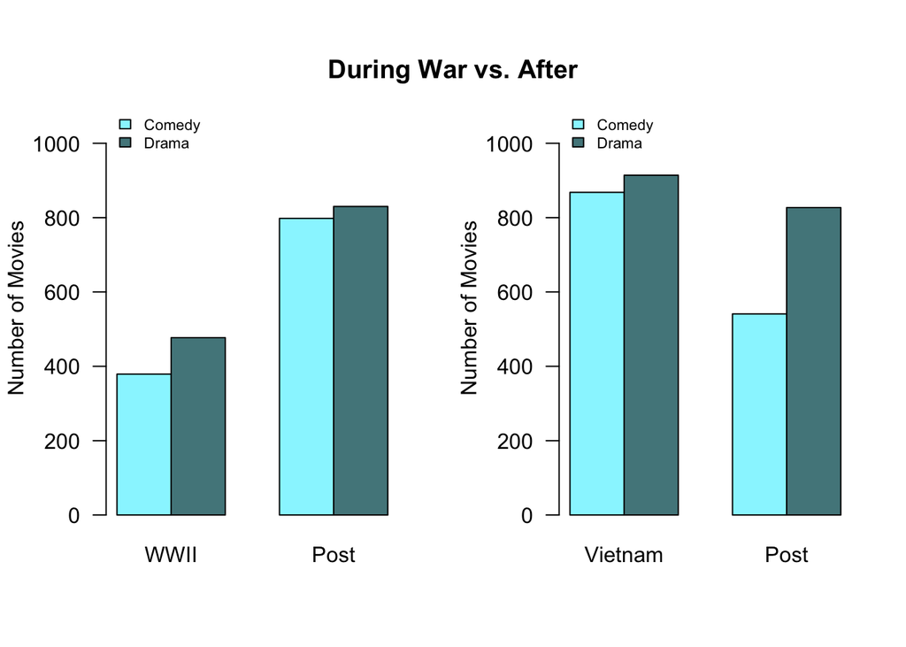

```r
par(mfrow= c(1,2))

barplot(t(rbind(WWII=apply(wwIIg1[,20:21], 2, sum), Post=apply(postwwII[,20:21], 2, sum))), beside=TRUE, col=c("cadetblue1", "cadetblue4"), args.legend = list(x = "topleft", cex = 0.70, bty="n"), legend.text=TRUE, ylab= " Number of Movies", las=1, ylim = c(0, 1100))

barplot(t(rbind(Vietnam=apply(vm[,20:21], 2, sum), Post=apply(pvm[,20:21], 2, sum))), beside=TRUE, col=c("cadetblue1", "cadetblue4"), legend.text=TRUE, ylab= " Number of Movies", args.legend = list(x = "topleft", cex = 0.70, bty="n"), las=1, ylim = c(0, 1100))

title(main="During War vs. After", line=-3, outer=TRUE)
```